# MNIST-Project

Andrew Clemons

3/31/2020

# Data Exploration

I began exploration by running PCA and creating an elbow plot. This showed that the largest amount of explanation from a Principle Components was less the 6%. This was expected as you need more than a few pixels to determine if it contributed to the picture. But, this showed that a large part of the data set could be removed as it didn’t contribute a significant amount of information. Here is the code, R doesn’t let me plot it.

```r
data.pca <- train[, apply(train, 2, var, na.rm = TRUE) != 0]
train.pca <- prcomp(data.pca, center =TRUE, scale = TRUE)
ggbiplot(train.pca)
train.var <- train.pca$sdev^2
pve <- train.var/sum(train.var)
plot(pve, xlab = "Principle Component",
     ylab = "Proportion of Variance Explained",
     ylim = c(0,.06), type = "b")
```

# Data Cleaning

The only cleaning I did to the data was what Professor Miller showed us in his demo. Removing columns that aren’t ever used help with the computational speed. I didn’t want to potentially reduce the accuracy of my model and the models were being ran in a reasonable amount of time so I didn’t remove near zero columns. If I needed to make the model faster, that would be one of the first places to start.

```r
train[,2:ncol(train)] <- train[2:ncol(train)]/255
zero_feature <- sapply(train[,2:ncol(train)], max) != 0
train <- train[,c(TRUE,zero_feature)]
train$label <- as.factor(train$label)
```

# Training Models

## Random Forest Model

I began by running the default Random Forest just to get a sumission to kaggle. I then created a Ranger template and a tune gride data frame. Ranger is faster than Random Forest and since I was creating a large amount of models with the tune grid, speed is very important. Then I used a for loop to create Ranger models using the values in my tune grid to then find the model parameters that result in the lowest RMSE.

```r
tune.grid <- expand.grid(mtry = seq(100, 200, by = 10),
                         num.trees = seq(400,500, by = 100),
                         node_size = seq(9,9, by =2),
                         sampe_size = c(.80),
                         OOB_RMSE = 0
                         )
```

Final Ranger Model

Kaggle Score 91%

```r
opt.ranger <- ranger(label~.,
                     data = train,
                     num.trees = 500,
                     mtry = 140,
                     min.node.size = 9,
                     sample.fraction = .8,
                     seed = 1
                     )
```

## SVM Model

I had a very similar approach to SVM’s as I did with Random Forest. I followed the process in the book and good very good results. I build polynomial and radial svm models because I wasn’t sure how to tell which would be better before hand. I created two vectors for cost and gamma and then used the tune function to tune them.

```r
c <- c(.001,.01,.1,1)
g <- c(.5,1,10)

tune.poly <- tune(svm, label~., data = train,
                  kernel = "polynomial",
                  ranges = list(cost = c, gamma = g))
```

I found that I was getting the same RMSE as I decreased cost and gamma. So I went back and selected cost and gamma that gave me the lowest RMSE so that I wouldn’t be overfitting my model. I got about a 97% score on Kaggle, which might have been a luck of the draw on my seed selection, which could compete with some Neural Networks.

Final Polynomial SVM model

Kaggle Score 97.6%

```r
train.opt.poly <- svm(label~., data = train, kernel = "polynomial", cost = .001, gamma = .5)
```

## Neural Network Model

Once I got my Neural Network working, I essentially brute forced the optimization of my Neural Netowork by building models on both my computer and within Kaggle’s notebooks. I worked through different combinations of hidden layers and then once I found one that gave me the best results I increased the iterations to get the highest score possible on Kaggle.

Final Neural Network

```r
nn1 <- mlp(x = split$inputsTrain, y = split$targetsTrain,
               size = c(25,25), maxit = 500,
               inputsTest = split$inputsTest,
               targetsTest = split$targetsTest)
```

# Accuracy

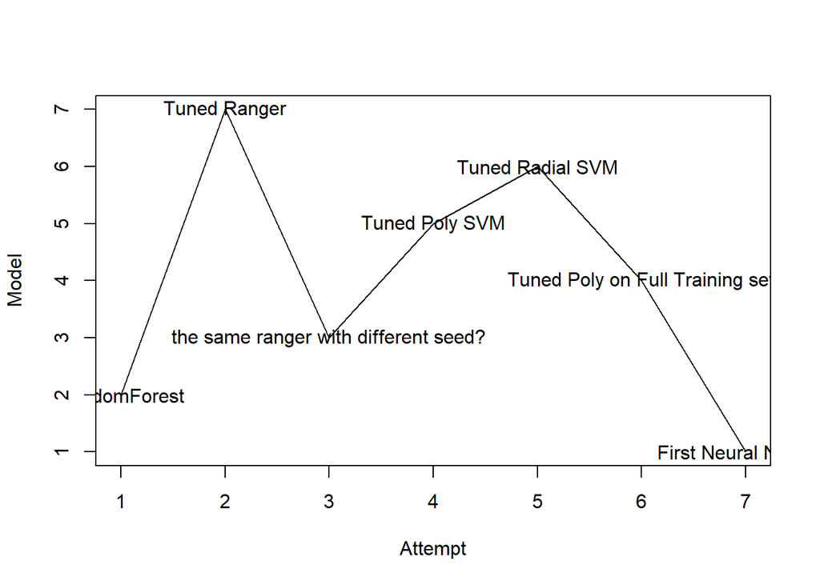

```r
progress <- data.frame("Attempt" = c(1,2,3,4,5,6,7),
                       "Score" = c(.42,.68,.91,.92,.11,.97,.88),
                       "Model" = c("RandomForest",
                                   "Tuned Ranger",
                                   "the same ranger with different seed?",
                                   "Tuned Poly SVM",
                                   "Tuned Radial SVM",
                                   "Tuned Poly on Full Training set",
                                   "First Neural Network"))

plot(x = progress$Attempt, y = progress$Model, "l", xlab = "Attempt", ylab = "Model")
text(x = progress$Attempt, y = progress$Model, labels = progress$Model, data = progress)
```